Skip to main content

# Media Sentiment on the Iran–Israel Conflict

- Show All Code
- Hide All Code
- View Source

A Cross-Country Analysis · January–April 2026

Author

Andrea Busolo

Published

November 27, 2026

## Introduction

How do newspapers in different countries report the Iran–Israel conflict? This report compares the sentiment of 3,138 articles published between **4 January and 4 April 2026** by 35 outlets in ten countries, plus Al Jazeera as a separate source. Sentiment is scored in each article’s own language with a multilingual transformer model, without translation.

## Data and Method

1. **Collection.** 51 outlets (five per country, one for Al Jazeera) were queried through the [GDELT Doc 2.0 API](https://blog.gdeltproject.org/gdelt-doc-2-0-api-debuts/) for articles containing all of *Iran*, *Israel*, *war* and *military*. The article date is the day GDELT first saw the URL. 11 outlets returned no URLs (see the coverage table).
2. **Scraping.** Full text extracted with `trafilatura`. Pages that could not be fetched (bot protection, JavaScript walls) are dropped, not replaced by snippets.
3. **Cleaning.** URLs from other sites that GDELT’s domain filter lets through are removed (for example `tagesspiegel.de` returned for `spiegel.de`). Consent banners, paywall notices and page furniture are stripped. Articles must have at least 100 words, duplicates are removed, and the detected language must match the outlet’s language.
4. **Sentiment.** [`cardiffnlp/xlm-roberta-base-sentiment-multilingual`](https://huggingface.co/cardiffnlp/xlm-roberta-base-sentiment-multilingual), an XLM-RoBERTa model fine-tuned on multilingual tweets, gives each text a probability of being negative, neutral and positive. Articles longer than 512 tokens are split into 510-token chunks with 50 tokens of overlap, and the chunk probabilities are averaged, weighted by chunk length.

## Dataset

### Outlet coverage

```r
coverage |>
  left_join(
    scores |>
      group_by(source_domain) |>
      summarise(avg_words = round(mean(word_count)),
                first = min(published_date), last = max(published_date), .groups = "drop"),
    by = "source_domain"
  ) |>
  arrange(country, desc(final_articles)) |>
  select(country, outlet_name, gdelt_urls, final_articles, avg_words, first, last) |>
  kbl(
    col.names = c("Country", "Outlet", "GDELT URLs", "Final articles", "Avg words",
                  "First seen", "Last seen"),
    caption = "All 51 queried outlets: URLs returned by GDELT (outlet's own site only) and articles in the final sample"
  ) |>
  kable_styling(bootstrap_options = c("striped", "hover", "condensed")) |>
  collapse_rows(columns = 1, valign = "top") |>
  scroll_box(height = "420px")
```

All 51 queried outlets: URLs returned by GDELT (outlet's own site only) and articles in the final sample

| Country | Outlet | GDELT URLs | Final articles | Avg words | First seen | Last seen |
| --- | --- | --- | --- | --- | --- | --- |
| Al Jazeera | Al-Jazeera English | 330 | 329 | 1025 | 2026-01-04 | 2026-04-04 |
| Argentina | Infobae | 14 | 14 | 1152 | 2026-03-03 | 2026-03-30 |
|  | Clarín | 11 | 11 | 1087 | 2026-02-19 | 2026-03-27 |
|  | La Nación | 5 | 5 | 1956 | 2026-03-10 | 2026-03-30 |
|  | Página 12 | 0 | 0 | NA | NA | NA |
|  | Perfil | 0 | 0 | NA | NA | NA |
| Brazil | Estadão | 3 | 3 | 686 | 2026-03-01 | 2026-04-01 |
|  | Veja | 1 | 1 | 403 | 2026-03-16 | 2026-03-16 |
|  | Folha de S.Paulo | 0 | 0 | NA | NA | NA |
|  | O Globo | 0 | 0 | NA | NA | NA |
|  | UOL | 0 | 0 | NA | NA | NA |
| Canada | Globe and Mail | 128 | 128 | 1381 | 2026-01-06 | 2026-04-04 |
|  | Toronto Star | 4 | 0 | NA | NA | NA |
|  | National Post | 61 | 0 | NA | NA | NA |
|  | CBC News | 71 | 0 | NA | NA | NA |
|  | CTV News | 0 | 0 | NA | NA | NA |
| France | BFM TV | 160 | 156 | 1509 | 2026-01-07 | 2026-04-04 |
|  | Le Parisien | 104 | 104 | 1097 | 2026-01-11 | 2026-04-02 |
|  | Le Figaro | 2 | 2 | 786 | 2026-03-04 | 2026-03-22 |
|  | Le Monde | 130 | 0 | NA | NA | NA |
|  | Libération | 0 | 0 | NA | NA | NA |
| Germany | Die Zeit | 51 | 49 | 550 | 2026-02-07 | 2026-04-03 |
|  | Süddeutsche Zeitung | 73 | 31 | 1447 | 2026-01-18 | 2026-04-04 |
|  | Bild | 21 | 21 | 462 | 2026-02-26 | 2026-03-30 |
|  | FAZ | 2 | 2 | 832 | 2026-01-16 | 2026-03-22 |
|  | Der Spiegel | 10 | 0 | NA | NA | NA |
| Israel | Jerusalem Post | 500 | 400 | 920 | 2026-01-05 | 2026-04-04 |
|  | Ynet News | 299 | 299 | 822 | 2026-01-04 | 2026-04-04 |
|  | Israel National News | 104 | 103 | 763 | 2026-01-04 | 2026-03-31 |
|  | Haaretz | 18 | 14 | 526 | 2026-01-09 | 2026-04-03 |
|  | Times of Israel | 0 | 0 | NA | NA | NA |
| Italy | Corriere della Sera | 83 | 83 | 1622 | 2026-01-11 | 2026-04-03 |
|  | ANSA | 109 | 73 | 1290 | 2026-01-19 | 2026-04-03 |
|  | La Stampa | 51 | 34 | 2852 | 2026-01-11 | 2026-04-04 |
|  | La Repubblica | 34 | 28 | 4851 | 2026-01-19 | 2026-04-03 |
|  | Il Sole 24 Ore | 23 | 22 | 848 | 2026-01-05 | 2026-04-02 |
| Spain | El Confidencial | 9 | 9 | 1652 | 2026-01-13 | 2026-03-31 |
|  | El País | 32 | 6 | 1020 | 2026-03-01 | 2026-04-01 |
|  | El Mundo | 4 | 4 | 1630 | 2026-02-26 | 2026-03-08 |
|  | ABC | 3 | 3 | 907 | 2026-03-02 | 2026-03-08 |
|  | La Vanguardia | 2 | 2 | 751 | 2026-03-30 | 2026-04-04 |
| UK | Daily Mail | 369 | 368 | 1272 | 2026-01-05 | 2026-04-04 |
|  | The Guardian | 253 | 253 | 1139 | 2026-01-05 | 2026-04-04 |
|  | The Independent | 253 | 215 | 919 | 2026-01-06 | 2026-04-04 |
|  | BBC News | 33 | 33 | 987 | 2026-01-12 | 2026-04-01 |
|  | The Times | 0 | 0 | NA | NA | NA |
| USA | CNN | 458 | 216 | 1321 | 2026-01-05 | 2026-04-04 |
|  | Fox News | 111 | 111 | 768 | 2026-01-05 | 2026-04-04 |
|  | New York Times | 6 | 6 | 1794 | 2026-03-08 | 2026-04-04 |
|  | Washington Post | 0 | 0 | NA | NA | NA |
|  | Wall Street Journal | 0 | 0 | NA | NA | NA |

11 of the 51 outlets returned no URLs at all, among them the Washington Post, the Wall Street Journal and the Times of Israel. Zero matching articles in three months of this war is implausible for outlets of that size. The most likely cause is GDELT’s rate limit: during collection, throttled or failed requests were counted as empty results. Le Monde returned 130 URLs, all of them JavaScript walls with no article text.

### From GDELT hits to the final sample

```r
attrition |>
  mutate(kept = percent(language_ok / gdelt, accuracy = 1)) |>
  arrange(desc(language_ok)) |>
  kbl(
    col.names = c("Country", "GDELT URLs", "Own site", "Scraped", "≥ 100 words",
                  "Deduplicated", "Final", "Kept"),
    caption = "Articles remaining after each pipeline step"
  ) |>
  kable_styling(bootstrap_options = c("striped", "condensed"))
```

Articles remaining after each pipeline step

| Country | GDELT URLs | Own site | Scraped | ≥ 100 words | Deduplicated | Final | Kept |
| --- | --- | --- | --- | --- | --- | --- | --- |
| UK | 1049 | 908 | 883 | 883 | 869 | 869 | 83% |
| Israel | 921 | 921 | 920 | 916 | 816 | 816 | 89% |
| USA | 575 | 575 | 575 | 574 | 417 | 333 | 58% |
| Al Jazeera | 330 | 330 | 329 | 329 | 329 | 329 | 100% |
| France | 396 | 396 | 392 | 262 | 262 | 262 | 66% |
| Italy | 300 | 300 | 300 | 266 | 245 | 240 | 80% |
| Canada | 264 | 264 | 128 | 128 | 128 | 128 | 48% |
| Germany | 186 | 157 | 147 | 145 | 103 | 103 | 55% |
| Argentina | 30 | 30 | 30 | 30 | 30 | 30 | 100% |
| Spain | 50 | 50 | 50 | 50 | 50 | 24 | 48% |
| Brazil | 4 | 4 | 4 | 4 | 4 | 4 | 100% |

The *own site* step removes 170 URLs that GDELT returned for the wrong outlet: its `domain:` filter matches suffixes, so local London papers came back as *The Independent* and Tagesspiegel as *Der Spiegel*, which is left with no articles. The other large losses are blocked pages (Canada, Le Monde), the same story under several URLs (CNN, Jerusalem Post) and pages in another language (CNN Arabic, El País in English).

### Articles per country

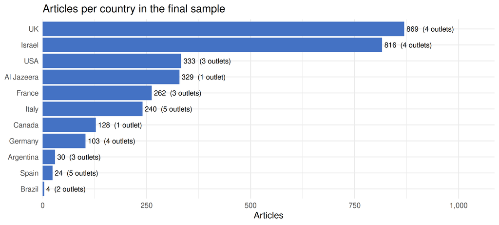

```r
scores |>
  count(country) |>
  left_join(coverage |> filter(final_articles > 0) |> count(country, name = "outlets"),
            by = "country") |>
  ggplot(aes(x = n, y = reorder(country, n))) +
  geom_col(fill = "#4472C4") +
  geom_text(aes(label = paste0(comma(n), "  (", outlets, " outlet", ifelse(outlets > 1, "s", ""), ")")),
            hjust = -0.05, size = 3.6) +
  scale_x_continuous(labels = comma, expand = expansion(mult = c(0, 0.25))) +
  labs(title = "Articles per country in the final sample", x = "Articles", y = NULL) +
  theme_minimal(base_size = 13)
```

### Weekly coverage

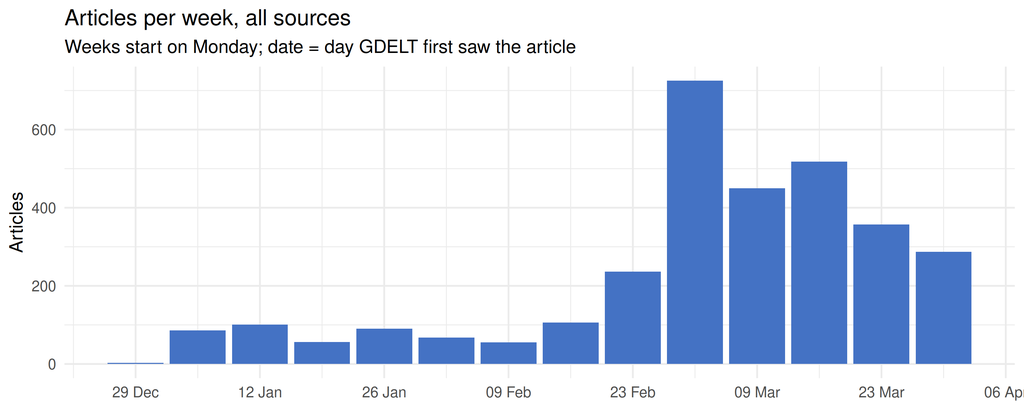

```r
scores |>
  count(week) |>
  ggplot(aes(x = week, y = n)) +
  geom_col(fill = "#4472C4") +
  scale_x_date(date_breaks = "2 weeks", date_labels = "%d %b") +
  scale_y_continuous(labels = comma) +
  labs(title = "Articles per week, all sources",
       subtitle = "Weeks start on Monday; date = day GDELT first saw the article",
       x = NULL, y = "Articles") +
  theme_minimal(base_size = 13)
```

Coverage is thin until mid-February, jumps in the week of 23 February and peaks in the week of 2 March (725 articles), when English headlines are dominated by *strikes*, *Tehran* and *Lebanon*; from mid-March they add *oil*, *Gulf* and *Hormuz*. 82% of the articles date from 23 February onwards, so the pooled results mostly describe that phase.

## Sentiment

Net sentiment is the article’s positive probability minus its negative probability, from −1 (certainly negative) to +1 (certainly positive).

### Average class probabilities by country

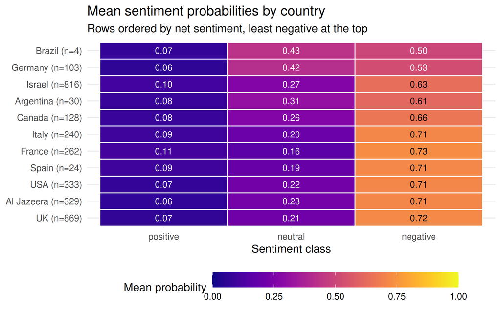

```r
country_avg |>
  pivot_longer(c(positive, neutral, negative), names_to = "sentiment", values_to = "prob") |>
  mutate(sentiment = factor(sentiment, levels = c("positive", "neutral", "negative"))) |>
  ggplot(aes(x = sentiment, y = reorder(label, net), fill = prob)) +
  geom_tile(color = "white", linewidth = 0.5) +
  geom_text(aes(label = sprintf("%.2f", prob), color = prob > 0.55), size = 3.6,
            show.legend = FALSE) +
  scale_color_manual(values = c("TRUE" = "black", "FALSE" = "white")) +
  scale_fill_viridis(option = "plasma", name = "Mean probability", limits = c(0, 1)) +
  labs(title = "Mean sentiment probabilities by country",
       subtitle = "Rows ordered by net sentiment, least negative at the top",
       x = "Sentiment class", y = NULL) +
  theme_minimal(base_size = 13) +
  theme(legend.position = "bottom", legend.key.width = unit(2, "cm"))
```

### Net sentiment by outlet

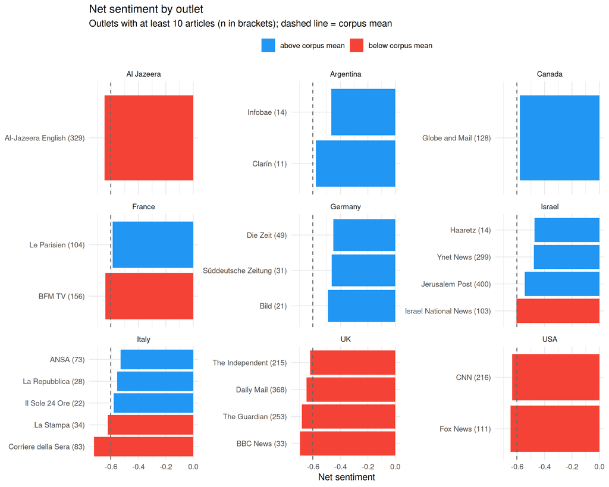

```r
outlet_avg |>
  filter(n >= MIN_OUTLET_N) |>
  mutate(
    direction = ifelse(net > corpus_mean, "above corpus mean", "below corpus mean"),
    outlet    = reorder(paste0(outlet_name, " (", n, ")"), net)
  ) |>
  ggplot(aes(x = net, y = outlet, fill = direction)) +
  geom_col() +
  geom_vline(xintercept = corpus_mean, linetype = "dashed", color = "grey40") +
  facet_wrap(~country, scales = "free_y", ncol = 3) +
  scale_fill_manual(values = c("above corpus mean" = "#2196F3", "below corpus mean" = "#F44336"),
                    name = NULL) +
  labs(
    title = "Net sentiment by outlet",
    subtitle = paste0("Outlets with at least ", MIN_OUTLET_N,
                      " articles (n in brackets); dashed line = corpus mean"),
    x = "Net sentiment", y = NULL
  ) +
  theme_minimal(base_size = 11) +
  theme(legend.position = "top")
```

Outlets in the same country can differ as much as countries do. In Italy, ANSA (−0.53) and Corriere della Sera (−0.72) sit near opposite ends of the full ranking, so a country average partly reflects which outlets happen to be in the sample.

### Distribution of net sentiment

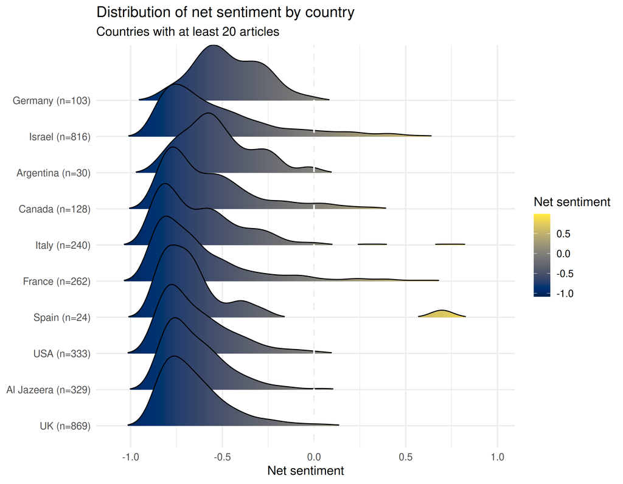

```r
scores |>
  filter(country %in% big_countries) |>
  left_join(select(country_avg, country, label), by = "country") |>
  mutate(label = reorder(label, bert_net, FUN = mean)) |>
  ggplot(aes(x = bert_net, y = label, fill = after_stat(x))) +
  geom_density_ridges_gradient(scale = 2, rel_min_height = 0.01) +
  scale_fill_viridis(option = "cividis", name = "Net sentiment") +
  geom_vline(xintercept = 0, linetype = "dashed", color = "white", linewidth = 0.8) +
  labs(
    title = "Distribution of net sentiment by country",
    subtitle = paste0("Countries with at least ", MIN_COUNTRY_N, " articles"),
    x = "Net sentiment", y = NULL
  ) +
  theme_minimal(base_size = 13)
```

The distributions overlap almost completely and sit below zero: 96.6% of all articles have negative net sentiment. The gap between the least and most negative countries (0.18) is smaller than the spread of single articles (standard deviation 0.25).

### Outlets ranked by net sentiment

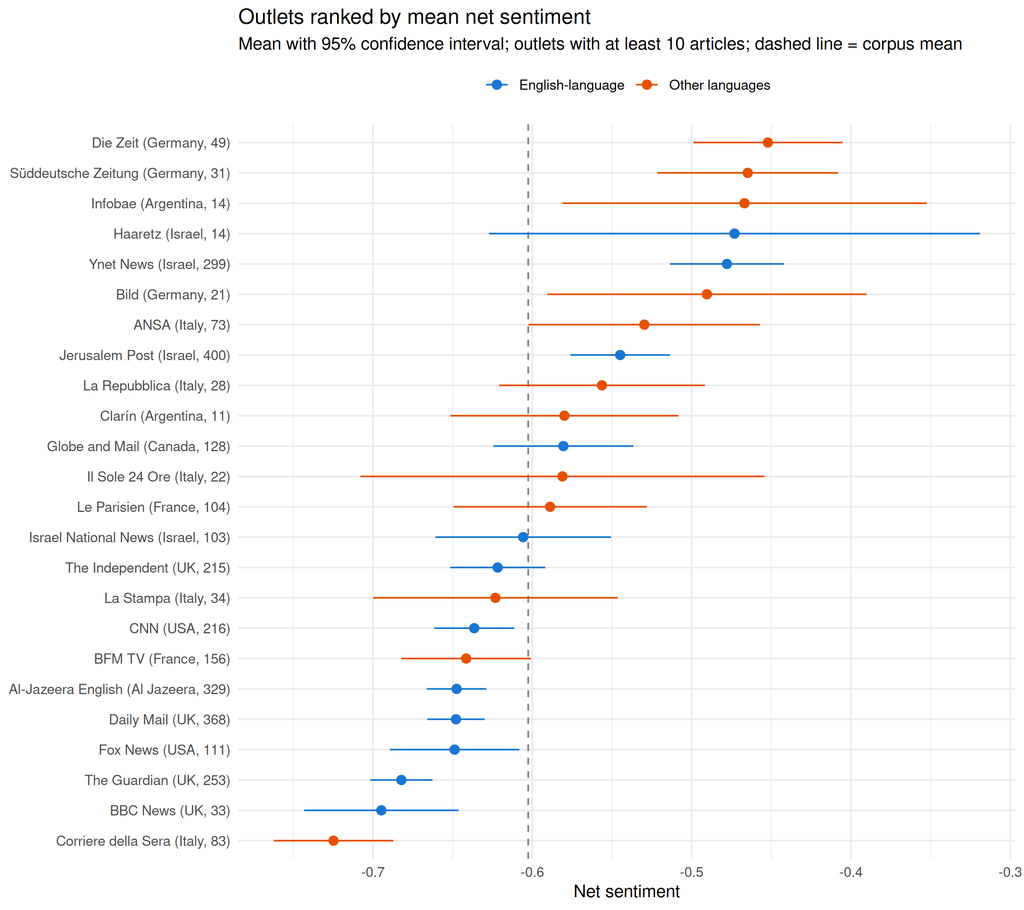

```r
outlet_avg |>
  filter(n >= MIN_OUTLET_N) |>
  mutate(
    label = reorder(paste0(outlet_name, " (", country, ", ", n, ")"), net),
    group = ifelse(english, "English-language", "Other languages")
  ) |>
  ggplot(aes(x = net, y = label, color = group)) +
  geom_vline(xintercept = corpus_mean, linetype = "dashed", color = "grey50") +
  geom_errorbar(aes(xmin = net - 1.96 * se, xmax = net + 1.96 * se), width = 0) +
  geom_point(size = 2.4) +
  scale_color_manual(values = c("English-language" = "#1976D2", "Other languages" = "#E65100"),
                     name = NULL) +
  labs(
    title = "Outlets ranked by mean net sentiment",
    subtitle = paste0("Mean with 95% confidence interval; outlets with at least ",
                      MIN_OUTLET_N, " articles; dashed line = corpus mean"),
    x = "Net sentiment", y = NULL
  ) +
  theme_minimal(base_size = 11) +
  theme(legend.position = "top")
```

German and Israeli outlets are the least negative; the BBC, the Guardian, Fox News, the Daily Mail, Al Jazeera and Corriere della Sera the most. With these sample sizes only gaps of about 0.1 or more are clearly distinguishable. Among English-language sources, Israeli outlets are less negative than the others by 0.12 (95% CI 0.09 to 0.14).

### Model confidence

GDELT tone scores are not available through the Doc API, so the model cannot be checked against them. As a weaker check, the chart shows the model’s **confidence**: the probability it gives to the class it picks. With three classes the minimum is 1/3.

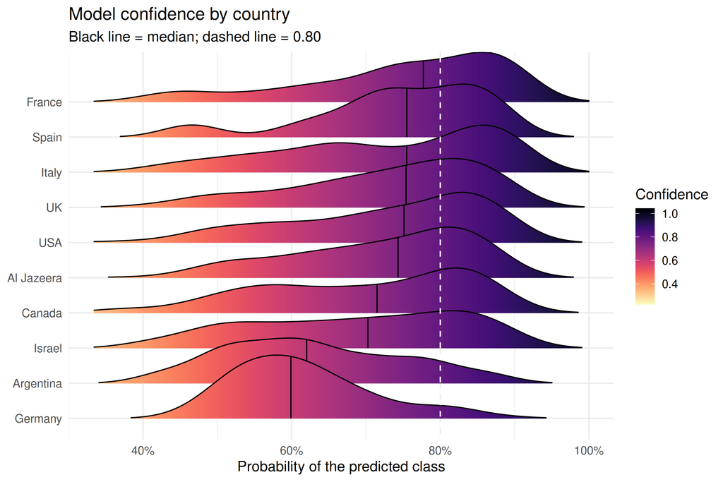

```r
scores |>
  filter(country %in% big_countries) |>
  mutate(
    confidence = pmax(bert_positive, bert_neutral, bert_negative),
    country    = reorder(country, confidence, FUN = median)
  ) |>
  ggplot(aes(x = confidence, y = country, fill = after_stat(x))) +
  geom_density_ridges_gradient(scale = 1.8, rel_min_height = 0.01,
                               quantile_lines = TRUE, quantiles = 2) +
  scale_fill_viridis(option = "magma", name = "Confidence", direction = -1) +
  scale_x_continuous(labels = percent_format(accuracy = 1), limits = c(1/3, 1)) +
  geom_vline(xintercept = 0.8, linetype = "dashed", color = "white", linewidth = 0.6) +
  labs(
    title = "Model confidence by country",
    subtitle = "Black line = median; dashed line = 0.80",
    x = "Probability of the predicted class", y = NULL
  ) +
  theme_minimal(base_size = 13)
```

Median confidence runs from 0.60 to 0.78: below 0.80 in every country, and only 7% to 44% of articles per country pass that mark. The model often hesitates between *negative* and *neutral* on long news texts, so the class shares in this report are better read as tendencies than as clean labels.

## Word Use

### Most frequent words per country

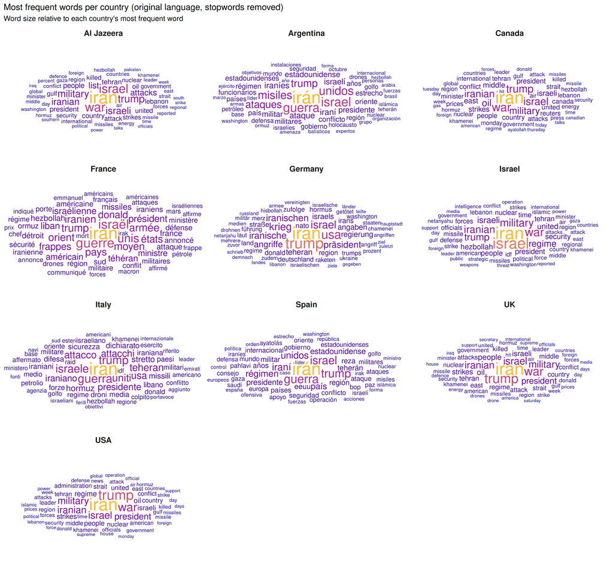

```r
tokens_clean |>
  count(country, word, sort = TRUE) |>
  group_by(country) |>
  slice_max(n, n = 60, with_ties = FALSE) |>
  mutate(rel = n / max(n)) |>          # size relative to each country's top word,
  ungroup() |>                         # so small countries stay readable
  ggplot(aes(label = word, size = rel, color = rel)) +
  geom_text_wordcloud(rm_outside = TRUE, seed = 42) +
  scale_size_area(max_size = 10) +
  scale_color_viridis_c(option = "plasma", end = 0.85) +
  facet_wrap(~country, ncol = 3) +
  theme_minimal(base_size = 12) +
  theme(strip.text = element_text(face = "bold", size = 13)) +
  labs(title = "Most frequent words per country (original language, stopwords removed)",
       subtitle = "Word size relative to each country's most frequent word")
```

Every country’s coverage is organised around the same actors: Iran, Israel, Trump and the United States, then the military vocabulary of strikes, missiles and forces. The clouds show *who* is covered, which is much the same everywhere, not *how*.

### Distinctive words among English-language sources (TF-IDF)

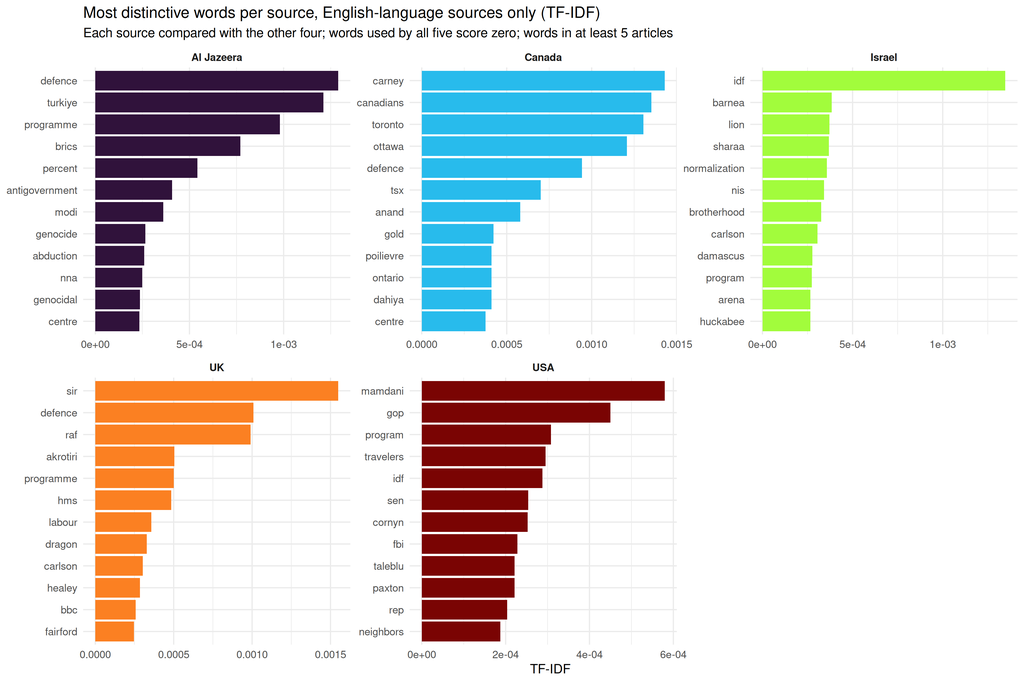

```r
tokens_clean |>
  filter(country %in% english_sources) |>
  add_count(country, word, name = "n") |>
  group_by(country, word) |>
  filter(n_distinct(article_id) >= 5) |>    # ignore names that appear in one or two articles
  summarise(n = first(n), .groups = "drop") |>
  bind_tf_idf(word, country, n) |>
  group_by(country) |>
  slice_max(tf_idf, n = 12, with_ties = FALSE) |>
  ungroup() |>
  mutate(word = reorder_within(word, tf_idf, country)) |>
  ggplot(aes(x = tf_idf, y = word, fill = country)) +
  geom_col(show.legend = FALSE) +
  facet_wrap(~country, scales = "free", ncol = 3) +
  scale_y_reordered() +
  scale_fill_viridis_d(option = "turbo") +
  labs(
    title = "Most distinctive words per source, English-language sources only (TF-IDF)",
    subtitle = "Each source compared with the other four; words used by all five score zero; words in at least 5 articles",
    x = "TF-IDF", y = NULL
  ) +
  theme_minimal(base_size = 11) +
  theme(strip.text = element_text(face = "bold"))
```

Restricting the comparison to English-language sources removes the language effect, which otherwise dominates TF-IDF. What remains is mostly each source’s home angle: Canadian politics and markets (Carney, Poilievre, the TSX), British defence (RAF, Akrotiri, HMS), US domestic politics (GOP, senators, the FBI), Israeli security and diplomacy (IDF, normalization, the shekel as *NIS*). Spelling conventions (*defence*, *programme*) also register. Al Jazeera is the only source with *genocide* and *genocidal* among its distinctive words.

### Most common two-word phrases

[figure not shown]

```r
texts |>
  unnest_tokens(bigram, full_text, token = "ngrams", n = 2) |>
  filter(!is.na(bigram)) |>
  separate(bigram, into = c("word1", "word2"), sep = " ") |>
  mutate(word1 = strip_elision(word1), word2 = strip_elision(word2)) |>
  anti_join(all_stopwords, by = c("word1" = "word", "language")) |>
  anti_join(all_stopwords, by = c("word2" = "word", "language")) |>
  filter(nchar(word1) > 2, nchar(word2) > 2,
         !str_detect(word1, "^\\d+$"), !str_detect(word2, "^\\d+$")) |>
  unite(bigram, word1, word2, sep = " ") |>
  count(country, bigram, sort = TRUE) |>
  group_by(country) |>
  slice_max(n, n = 10, with_ties = FALSE) |>
  ungroup() |>
  mutate(bigram = reorder_within(bigram, n, country)) |>
  ggplot(aes(x = n, y = bigram, fill = country)) +
  geom_col(show.legend = FALSE) +
  facet_wrap(~country, scales = "free", ncol = 3) +
  scale_y_reordered() +
  scale_fill_viridis_d(option = "turbo") +
  labs(title = "Most common two-word phrases per country", x = "Count", y = NULL) +
  theme_minimal(base_size = 11) +
  theme(strip.text = element_text(face = "bold"))
```

*Donald Trump* is among the top three phrases in every country, Iran’s *supreme leader* or the *Islamic Republic* appear everywhere, and *Middle East* leads in most. The phrases are names of people, places and institutions; few carry any evaluation, which is one reason word counts alone say little about tone.

## Sentiment over Time

### Weekly net sentiment, all sources

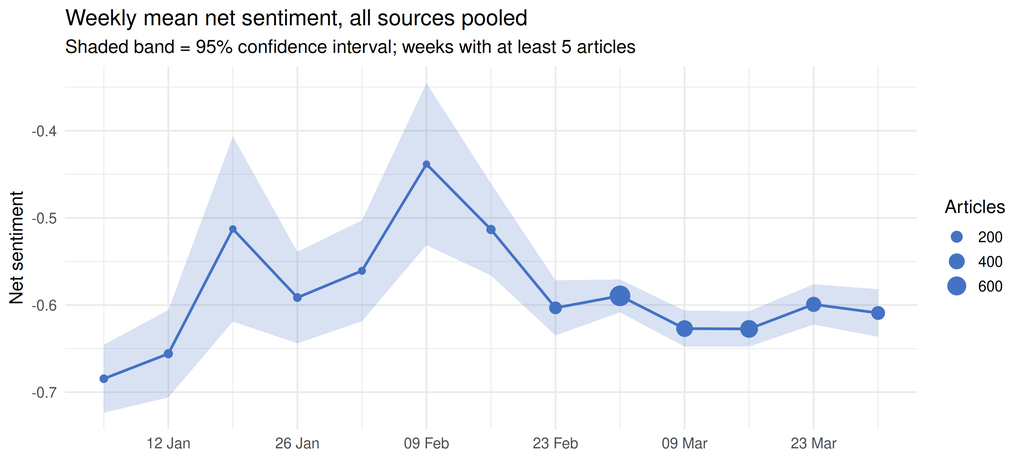

```r
ggplot(weekly_all, aes(x = week, y = net)) +
  geom_ribbon(aes(ymin = net - 1.96 * se, ymax = net + 1.96 * se), fill = "#4472C4", alpha = 0.2) +
  geom_line(color = "#4472C4", linewidth = 0.9) +
  geom_point(aes(size = n), color = "#4472C4") +
  scale_size_area(max_size = 6, name = "Articles") +
  scale_x_date(date_breaks = "2 weeks", date_labels = "%d %b") +
  labs(
    title = "Weekly mean net sentiment, all sources pooled",
    subtitle = paste0("Shaded band = 95% confidence interval; weeks with at least ", MIN_WEEK_N, " articles"),
    x = NULL, y = "Net sentiment"
  ) +
  theme_minimal(base_size = 13)
```

Weekly means range from −0.68 (week of 5 January) to −0.44 (week of 9 February, 55 articles). From the late-February escalation onwards they settle around −0.60 with narrow bands. Busier weeks tend to be more negative (correlation −0.32 across the 13 weeks shown), which with so few points is suggestive at most.

### 7-day rolling net sentiment by country

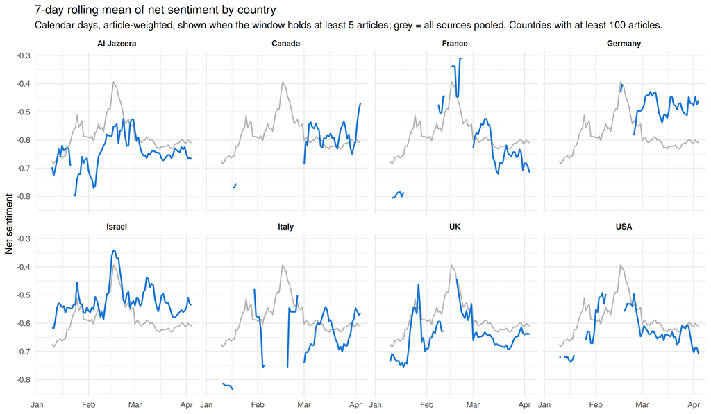

```r
rolling |>
  ggplot(aes(x = published_date, y = net7)) +
  geom_line(data = rolling_all |> select(-any_of("country")), color = "grey70",
            linewidth = 0.7, na.rm = TRUE) +
  geom_line(color = "#1976D2", linewidth = 0.9, na.rm = TRUE) +
  facet_wrap(~country, ncol = 4) +
  scale_x_date(date_breaks = "1 month", date_labels = "%b") +
  labs(
    title = "7-day rolling mean of net sentiment by country",
    subtitle = paste0("Calendar days, article-weighted, shown when the window holds at least 5 articles; ",
                      "grey = all sources pooled. Countries with at least 100 articles."),
    x = NULL, y = "Net sentiment"
  ) +
  theme_minimal(base_size = 12) +
  theme(strip.text = element_text(face = "bold"))
```

Gaps mark stretches with fewer than five articles in seven days, which covers much of January and February outside Israel, the UK and Al Jazeera. From March onwards Germany and Israel stay above the pooled line, while the UK, the USA and Al Jazeera run slightly below it, the same order as in the country averages.

### Weekly net sentiment per outlet

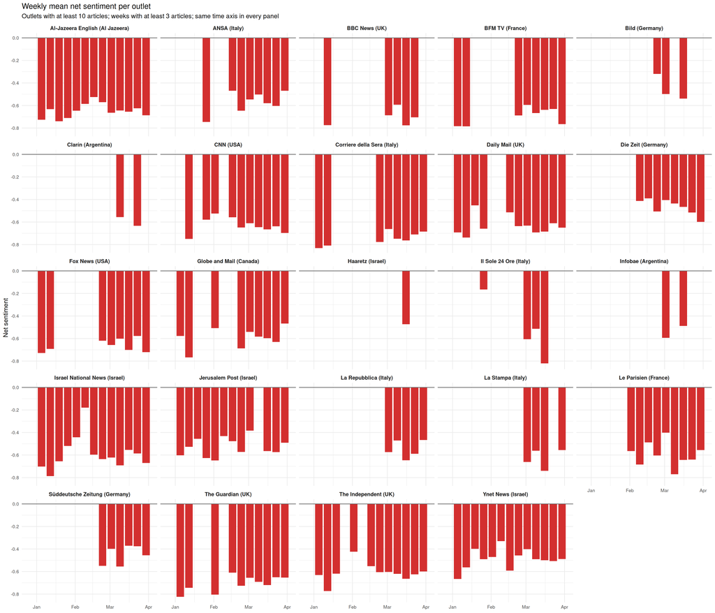

```r
scores |>
  add_count(outlet_name, name = "outlet_n") |>
  filter(outlet_n >= MIN_OUTLET_N) |>
  group_by(country, outlet_name, week) |>
  summarise(net = mean(bert_net), n = n(), .groups = "drop") |>
  filter(n >= 3) |>
  mutate(panel = paste0(outlet_name, " (", country, ")")) |>
  ggplot(aes(x = week, y = net)) +
  geom_col(width = 6, fill = "#D32F2F") +
  geom_hline(yintercept = 0, color = "grey40") +
  facet_wrap(~panel, ncol = 5) +
  scale_x_date(date_labels = "%b", limits = range(scores$week) + c(-4, 4)) +
  labs(
    title = "Weekly mean net sentiment per outlet",
    subtitle = paste0("Outlets with at least ", MIN_OUTLET_N,
                      " articles; weeks with at least 3 articles; same time axis in every panel"),
    x = NULL, y = "Net sentiment"
  ) +
  theme_minimal(base_size = 9) +
  theme(strip.text = element_text(size = 7.5, face = "bold"), axis.text = element_text(size = 6.5))
```

No outlet is net positive in any week. Most outlets only reach three articles a week from late February, so the early bars come mainly from the Israeli and British outlets and Al Jazeera.

### Week-to-week volatility

The spread of weekly means mixes real change with sampling noise: a week with few articles has a noisy mean. The chart compares the observed spread with the spread that noise alone would produce.

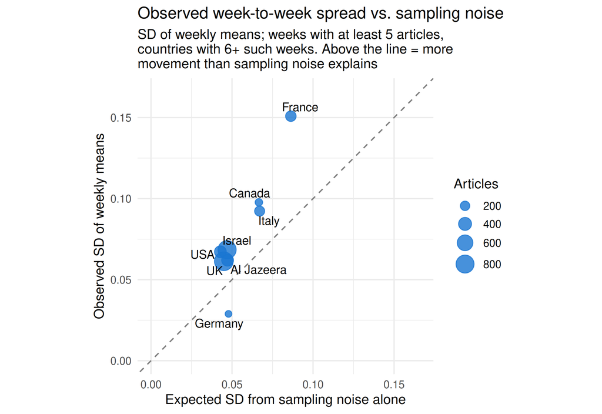

```r
volatility <- weekly_country |>
  filter(n >= MIN_WEEK_N) |>
  group_by(country) |>
  filter(n() >= 6) |>
  summarise(
    observed = sd(net),
    noise    = sqrt(mean(var / n)),
    weeks    = n(),
    articles = sum(n),
    .groups  = "drop"
  )

lim <- c(0, max(c(volatility$observed, volatility$noise)) * 1.1)
volatility |>
  ggplot(aes(x = noise, y = observed, label = country)) +
  geom_abline(slope = 1, intercept = 0, linetype = "dashed", color = "grey50") +
  geom_point(aes(size = articles), color = "#1976D2", alpha = 0.8) +
  ggrepel::geom_text_repel(size = 4) +
  scale_size_area(max_size = 8, name = "Articles") +
  coord_equal(xlim = lim, ylim = lim) +
  labs(
    title = "Observed week-to-week spread vs. sampling noise",
    subtitle = paste0("SD of weekly means; weeks with at least ", MIN_WEEK_N,
                      " articles,\ncountries with 6+ such weeks. Above the line = more\nmovement than sampling noise explains"),
    x = "Expected SD from sampling noise alone", y = "Observed SD of weekly means"
  ) +
  theme_minimal(base_size = 13)
```

7 of the 8 countries move more than sampling noise alone would produce, by a factor of 1.3 to 1.7, with France the most changeable. Germany’s weekly means vary less than noise would predict, but with only 6 weeks of enough articles.

## Conclusions

### What the data show

- **Coverage is overwhelmingly negative.** 89% of articles are classified negative, 9% neutral and 2% positive. Mean net sentiment is −0.60, and no outlet is net positive in any week.
- **Country differences exist but are small.** German (−0.47) and Israeli (−0.53) coverage is the least negative; British, Al Jazeera and US coverage the most (−0.65 to −0.64). Countries differ less than single articles do, and outlets within one country can differ as much as countries (ANSA and Corriere della Sera in Italy).
- **Israeli outlets are less negative than other English-language outlets**, by about 0.12. This is the cleanest comparison in the report because the language is held fixed, and it is not a matter of timing: the gap is the same in January–February and in March–April. Their distinctive vocabulary is domestic: the IDF, normalization, the shekel.
- **The escalation changed the volume more than the tone.** Coverage rose from about 76 articles a week in January and early February to 725 in the week of 2 March. Weekly sentiment stayed within a narrow band, slightly more negative in the busier weeks.

### Comments

- **The model measures tone, not position.** The classifier was trained on tweets labelled for the writer’s feeling. In war reporting, *negative* mostly records the subject (strikes, casualties, threats), not an attitude towards Iran, Israel or the United States: a critical and a sympathetic account of the same airstrike can both score strongly negative. Claims about bias or framing would need a stance measure aimed at each actor.
- **Comparisons across languages are fragile.** The model is not equally calibrated in every language. German coverage is the least negative and the most neutral, and it is so for the tabloid Bild as much as for Die Zeit and the Süddeutsche Zeitung. Part of the gap is genre: liveblogs and agency copy read as less negative in every country, and much of the German sample is one or the other. Among the 42 German articles that are neither, the gap to other countries shrinks from 0.14 to about 0.10, but their neutral probability stays far higher (0.38 against 0.22). That residue points to how the model reads German rather than to editorial style, though 42 articles cannot settle it. Comparisons within one language, such as the English-language sources, are the ones to trust.
- **Genre mix shifts averages.** Because liveblogs and wire copy are less negative everywhere, an outlet’s or country’s average partly reflects how much of its sample is live or agency copy (ANSA in Italy is an example).
- **The labels are soft.** Median confidence stays below 0.80 in every country. Class shares are tendencies, and the net score, which uses the full probabilities, is the better summary.
- **The sample is not a census.** Eleven outlets returned nothing, most likely because GDELT throttled the requests and they were counted as empty. The four-word query (*Iran*, *Israel*, *war*, *military*) favours explicitly military stories, and the UK and Israel make up over half of the articles. The results describe this sample, not each country’s press as a whole.
- **Next steps.** Hand-code a sample of articles in each language to measure the model’s accuracy before comparing countries. Measure stance towards named actors instead of overall tone. Re-collect with a fixed number of outlets per country, logging throttled queries so that they are not mistaken for outlets with no coverage. Compare countries with article-level regressions that include outlet and week effects, so that differences in timing and outlet mix are not read as national differences.

## Reproducibility

Code: github.com/andbbus/war-sentiment. Article text is not redistributed. The repository ships GDELT metadata and per-article scores, so every section except *Word Use* renders from the repository alone.

The sentiment scores were computed on CPU. An earlier run on Apple silicon gives the same scores to within 0.00001 for the 2,308 articles whose cleaned text is identical in both runs (identical labels in every case).

```bash
python -m venv .venv && source .venv/bin/activate
pip install -r requirements.txt

python -m src.collect.gdelt_query     # 1. GDELT metadata (sequential, ~1 request / 5.5 s)
python -m src.collect.scraper         # 2. full text (not redistributed)
python -m src.preprocess.pipeline     # 3. cleaning, deduplication, language check
python -m src.sentiment.inference     # 4. sentiment scores
python -m src.sentiment.export        # 5. text-free summaries and scores
quarto render                         # 6. this report, written to docs/
```